# Loan Data Visualisation and Cleaning

2025-10-07

## Introduction

We will start by loading any required libraries and reading the data.

```r
library(tidyverse)
library(Hmisc)
library(scales)
library(corrplot)
library(rpart)
library(rpart.plot)
library(caret)
```

```r
loan <- read_csv("../dataset/loan_data.csv", col_types ="nffnnfnfnnnnff")
```

## Summary Statistics

First we will explore some summary statistic of the whole data set:

```r
# View the first 10 rows of the data frame
head(loan, 10)
```

```
## # A tibble: 10 × 14
##    person_age person_gender person_education person_income person_emp_exp
##         <dbl> <fct>         <fct>                    <dbl>          <dbl>
##  1         22 female        Master                   71948              0
##  2         21 female        High School              12282              0
##  3         25 female        High School              12438              3
##  4         23 female        Bachelor                 79753              0
##  5         24 male          Master                   66135              1
##  6         21 female        High School              12951              0
##  7         26 female        Bachelor                 93471              1
##  8         24 female        High School              95550              5
##  9         24 female        Associate               100684              3
## 10         21 female        High School              12739              0
## # ℹ 9 more variables: person_home_ownership <fct>, loan_amnt <dbl>,
## #   loan_intent <fct>, loan_int_rate <dbl>, loan_percent_income <dbl>,
## #   cb_person_cred_hist_length <dbl>, credit_score <dbl>,
## #   previous_loan_defaults_on_file <fct>, loan_status <fct>
```

```r
# Gives the dimensions of the data frame
dim(loan)
```

```
## [1] 45000    14
```

```r
# Structure of data
str(loan)
```

```
## spc_tbl_ [45,000 × 14] (S3: spec_tbl_df/tbl_df/tbl/data.frame)
##  $ person_age                    : num [1:45000] 22 21 25 23 24 21 26 24 24 21 ...
##  $ person_gender                 : Factor w/ 2 levels "female","male": 1 1 1 1 2 1 1 1 1 1 ...
##  $ person_education              : Factor w/ 5 levels "Master","High School",..: 1 2 2 3 1 2 3 2 4 2 ...
##  $ person_income                 : num [1:45000] 71948 12282 12438 79753 66135 ...
##  $ person_emp_exp                : num [1:45000] 0 0 3 0 1 0 1 5 3 0 ...
##  $ person_home_ownership         : Factor w/ 4 levels "RENT","OWN","MORTGAGE",..: 1 2 3 1 1 2 1 1 1 2 ...
##  $ loan_amnt                     : num [1:45000] 35000 1000 5500 35000 35000 2500 35000 35000 35000 1600 ...
##  $ loan_intent                   : Factor w/ 6 levels "PERSONAL","EDUCATION",..: 1 2 3 3 3 4 2 3 1 4 ...
##  $ loan_int_rate                 : num [1:45000] 16 11.1 12.9 15.2 14.3 ...
##  $ loan_percent_income           : num [1:45000] 0.49 0.08 0.44 0.44 0.53 0.19 0.37 0.37 0.35 0.13 ...
##  $ cb_person_cred_hist_length    : num [1:45000] 3 2 3 2 4 2 3 4 2 3 ...
##  $ credit_score                  : num [1:45000] 561 504 635 675 586 532 701 585 544 640 ...
##  $ previous_loan_defaults_on_file: Factor w/ 2 levels "No","Yes": 1 2 1 1 1 1 1 1 1 1 ...
##  $ loan_status                   : Factor w/ 2 levels "1","0": 1 2 1 1 1 1 1 1 1 1 ...
##  - attr(*, "spec")=
##   .. cols(
##   ..   person_age = col_number(),
##   ..   person_gender = col_factor(levels = NULL, ordered = FALSE, include_na = FALSE),
##   ..   person_education = col_factor(levels = NULL, ordered = FALSE, include_na = FALSE),
##   ..   person_income = col_number(),
##   ..   person_emp_exp = col_number(),
##   ..   person_home_ownership = col_factor(levels = NULL, ordered = FALSE, include_na = FALSE),
##   ..   loan_amnt = col_number(),
##   ..   loan_intent = col_factor(levels = NULL, ordered = FALSE, include_na = FALSE),
##   ..   loan_int_rate = col_number(),
##   ..   loan_percent_income = col_number(),
##   ..   cb_person_cred_hist_length = col_number(),
##   ..   credit_score = col_number(),
##   ..   previous_loan_defaults_on_file = col_factor(levels = NULL, ordered = FALSE, include_na = FALSE),
##   ..   loan_status = col_factor(levels = NULL, ordered = FALSE, include_na = FALSE)
##   .. )
##  - attr(*, "problems")=<externalptr>
```

```r
# Summary of the whole data
summary(loan)
```

```
##    person_age     person_gender     person_education person_income
##  Min.   : 20.00   female:20159   Master     : 6980   Min.   :   8000
##  1st Qu.: 24.00   male  :24841   High School:11972   1st Qu.:  47204
##  Median : 26.00                  Bachelor   :13399   Median :  67048
##  Mean   : 27.76                  Associate  :12028   Mean   :  80319
##  3rd Qu.: 30.00                  Doctorate  :  621   3rd Qu.:  95789
##  Max.   :144.00                                      Max.   :7200766
##  person_emp_exp   person_home_ownership   loan_amnt
##  Min.   :  0.00   RENT    :23443        Min.   :  500
##  1st Qu.:  1.00   OWN     : 2951        1st Qu.: 5000
##  Median :  4.00   MORTGAGE:18489        Median : 8000
##  Mean   :  5.41   OTHER   :  117        Mean   : 9583
##  3rd Qu.:  8.00                         3rd Qu.:12237
##  Max.   :125.00                         Max.   :35000
##             loan_intent   loan_int_rate   loan_percent_income
##  PERSONAL         :7552   Min.   : 5.42   Min.   :0.0000
##  EDUCATION        :9153   1st Qu.: 8.59   1st Qu.:0.0700
##  MEDICAL          :8548   Median :11.01   Median :0.1200
##  VENTURE          :7819   Mean   :11.01   Mean   :0.1397
##  HOMEIMPROVEMENT  :4783   3rd Qu.:12.99   3rd Qu.:0.1900
##  DEBTCONSOLIDATION:7145   Max.   :20.00   Max.   :0.6600
##  cb_person_cred_hist_length  credit_score   previous_loan_defaults_on_file
##  Min.   : 2.000             Min.   :390.0   No :22142
##  1st Qu.: 3.000             1st Qu.:601.0   Yes:22858
##  Median : 4.000             Median :640.0
##  Mean   : 5.867             Mean   :632.6
##  3rd Qu.: 8.000             3rd Qu.:670.0
##  Max.   :30.000             Max.   :850.0
##  loan_status
##  1:10000
##  0:35000
##
##
##
##
```

```r
# Summary of the numeric data
loan %>% keep(is.numeric) %>% summary()
```

```
##    person_age     person_income     person_emp_exp     loan_amnt
##  Min.   : 20.00   Min.   :   8000   Min.   :  0.00   Min.   :  500
##  1st Qu.: 24.00   1st Qu.:  47204   1st Qu.:  1.00   1st Qu.: 5000
##  Median : 26.00   Median :  67048   Median :  4.00   Median : 8000
##  Mean   : 27.76   Mean   :  80319   Mean   :  5.41   Mean   : 9583
##  3rd Qu.: 30.00   3rd Qu.:  95789   3rd Qu.:  8.00   3rd Qu.:12237
##  Max.   :144.00   Max.   :7200766   Max.   :125.00   Max.   :35000
##  loan_int_rate   loan_percent_income cb_person_cred_hist_length  credit_score
##  Min.   : 5.42   Min.   :0.0000      Min.   : 2.000             Min.   :390.0
##  1st Qu.: 8.59   1st Qu.:0.0700      1st Qu.: 3.000             1st Qu.:601.0
##  Median :11.01   Median :0.1200      Median : 4.000             Median :640.0
##  Mean   :11.01   Mean   :0.1397      Mean   : 5.867             Mean   :632.6
##  3rd Qu.:12.99   3rd Qu.:0.1900      3rd Qu.: 8.000             3rd Qu.:670.0
##  Max.   :20.00   Max.   :0.6600      Max.   :30.000             Max.   :850.0
```

```r
# Summary of the catagorical data
loan %>%  keep(is.factor) %>%  summary()  ### summary of factors variables
```

```
##  person_gender     person_education person_home_ownership
##  female:20159   Master     : 6980   RENT    :23443
##  male  :24841   High School:11972   OWN     : 2951
##                 Bachelor   :13399   MORTGAGE:18489
##                 Associate  :12028   OTHER   :  117
##                 Doctorate  :  621
##
##             loan_intent   previous_loan_defaults_on_file loan_status
##  PERSONAL         :7552   No :22142                      1:10000
##  EDUCATION        :9153   Yes:22858                      0:35000
##  MEDICAL          :8548
##  VENTURE          :7819
##  HOMEIMPROVEMENT  :4783
##  DEBTCONSOLIDATION:7145
```

## Visulalisation

### Count Data

Below shows a histograms of the numeric variables

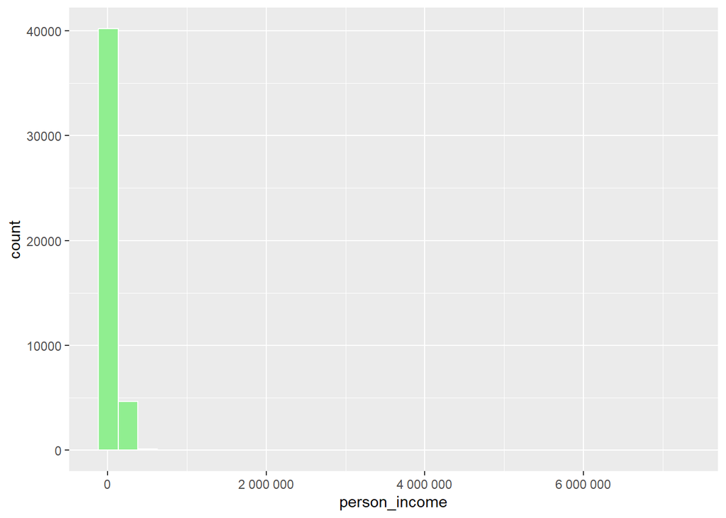

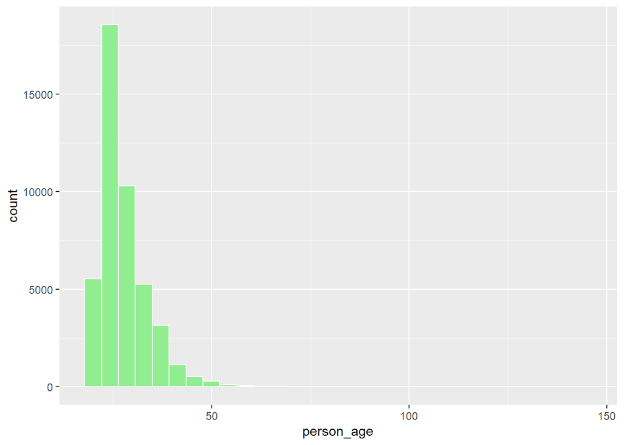

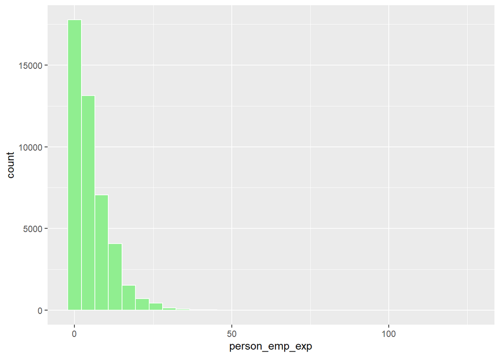

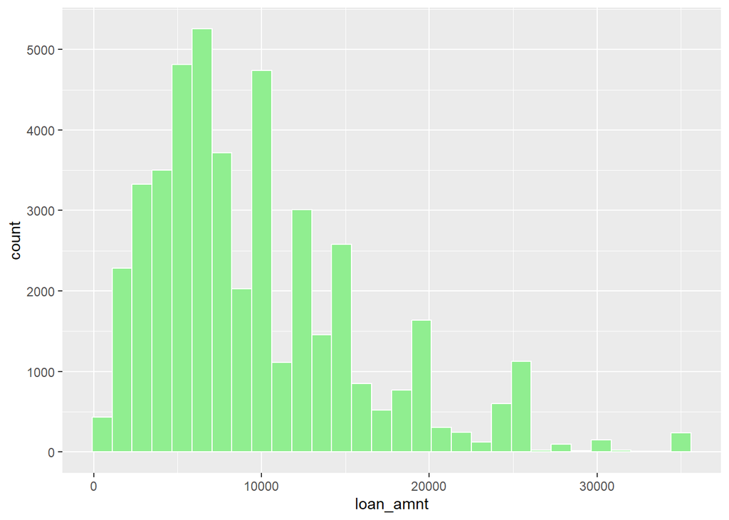

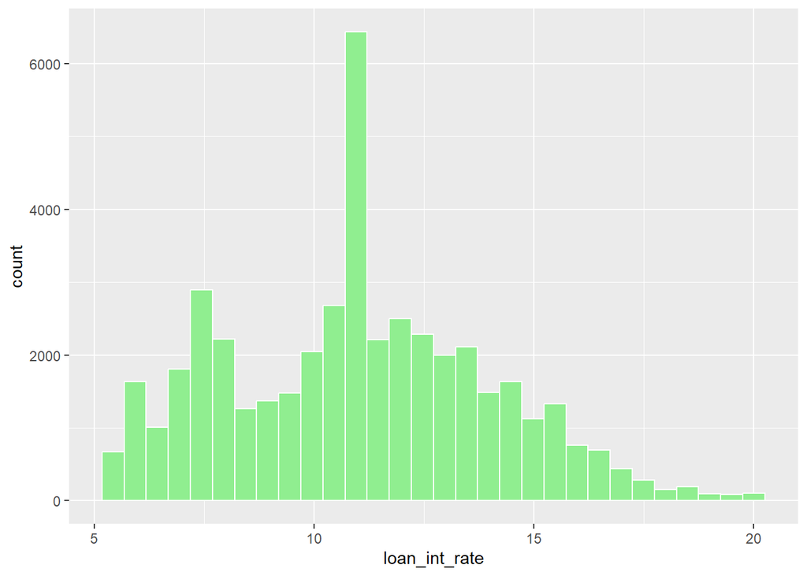

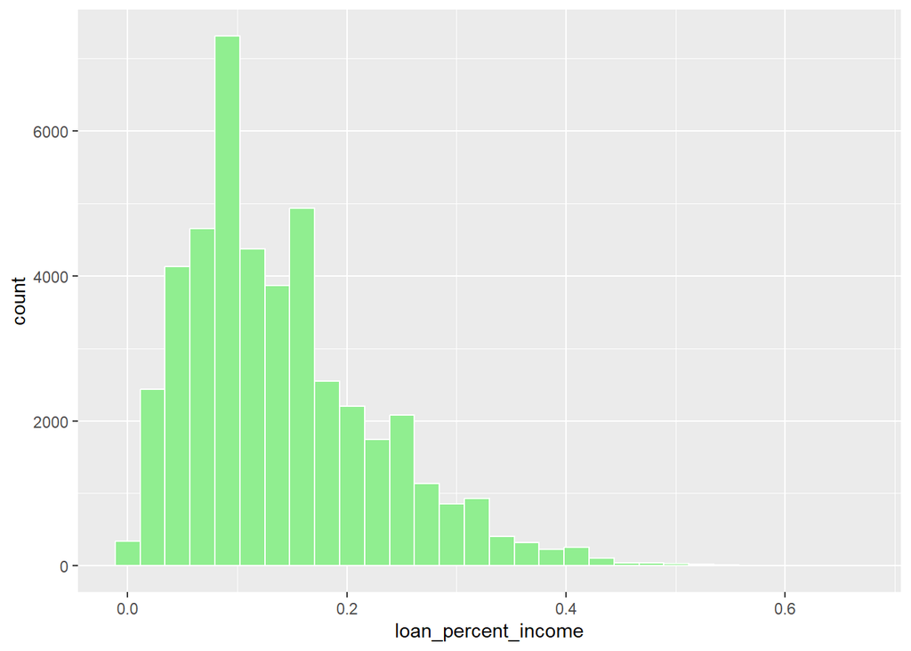

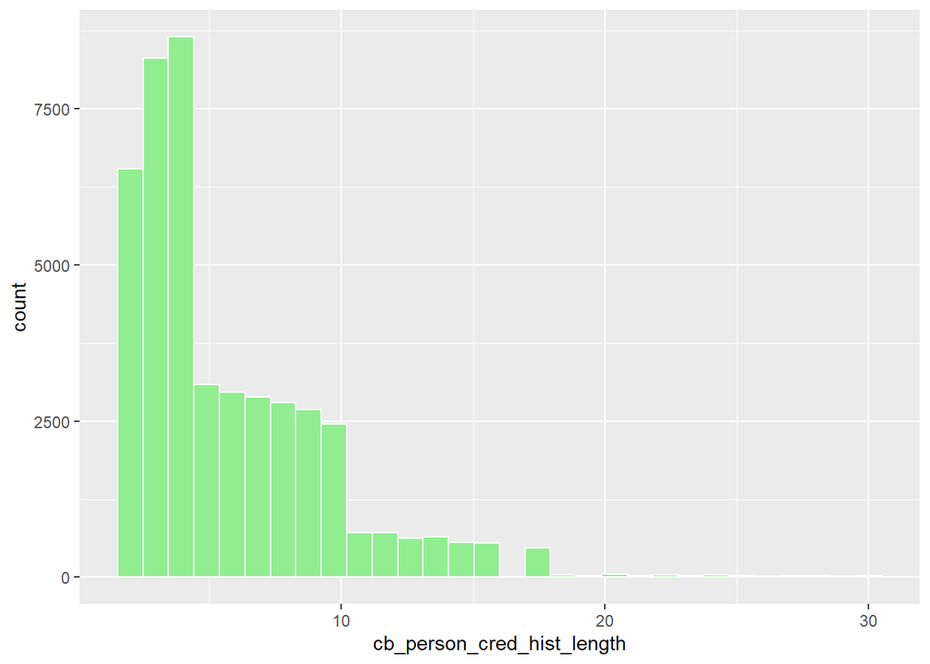

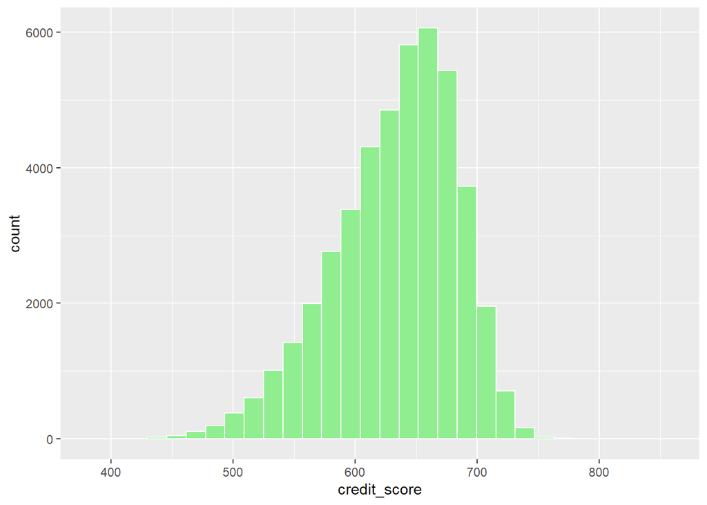

```r
ggplot(loan, aes(x=person_income)) +
  geom_histogram(position="identity", fill = "lightgreen", col = "white")+
  scale_x_continuous(labels = label_number())

ggplot(loan, aes(x=person_age, colour = "white")) +
  geom_histogram(position="identity", fill = "lightgreen", col = "white")

ggplot(loan, aes(x=person_emp_exp, colour = "white")) +
  geom_histogram(position="identity", fill = "lightgreen", col = "white")

ggplot(loan, aes(x=loan_amnt, colour = "white")) +
  geom_histogram(position="identity", fill = "lightgreen", col = "white")

ggplot(loan, aes(x=loan_int_rate, colour = "white")) +
  geom_histogram(position="identity", fill = "lightgreen", col = "white")

ggplot(loan, aes(x=loan_percent_income, colour = "white")) +
  geom_histogram(position="identity", fill = "lightgreen", col = "white")

ggplot(loan, aes(x=cb_person_cred_hist_length, colour = "white")) +
  geom_histogram(position="identity", fill = "lightgreen", col = "white")

ggplot(loan, aes(x=credit_score, colour = "white")) +
  geom_histogram(position="identity", fill = "lightgreen", col = "white")
```

The first three histograms showing the variables person_income, person_age and person_emp_exp do not tell us much about any trends in this variable as the majority of the data in the lower bins but there is a few data points that are much higher. in order to gain insight on this variable we will reduce the data to those observations in the most populated bins and then create a histogram of this data. This is shown below:

```r
# Check where to cut the data of by finding the percentage of data that is still left - don't want to reduce it too much.
(count(subset(loan, person_income <= 400000))/count(loan))*100
```

```
##          n
## 1 99.63333
```

```r
(count(subset(loan, person_age < 60))/count(loan))*100
```

```
##          n
## 1 99.79111
```

```r
(count(subset(loan, person_emp_exp < 40))/count(loan))*100
```

```
##          n
## 1 99.83778
```

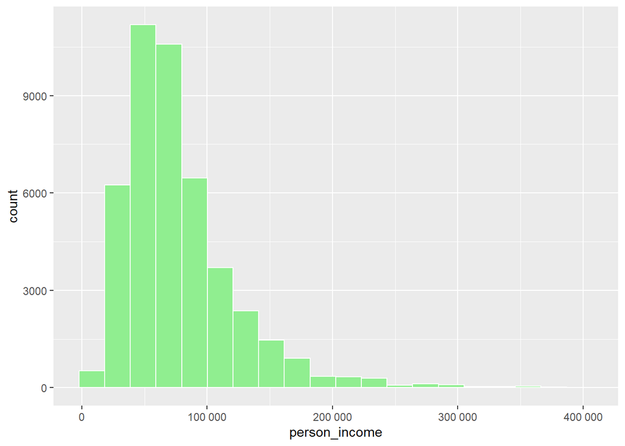

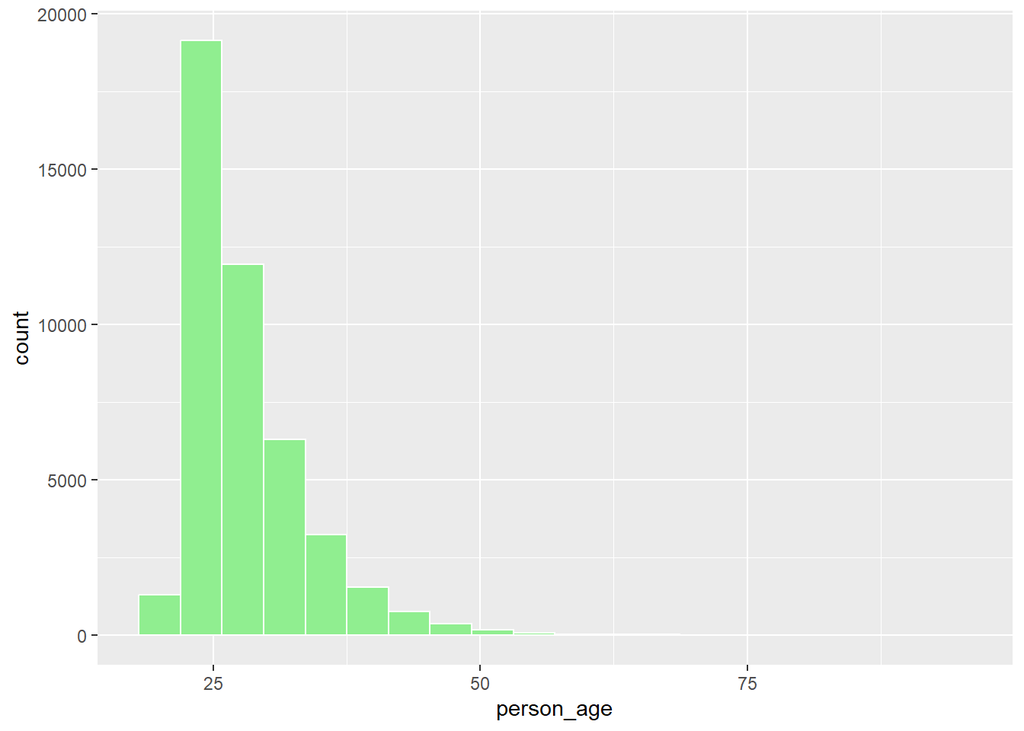

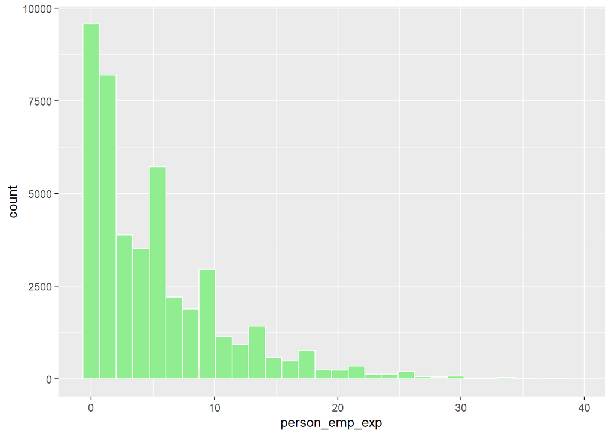

```r
# These cut off points still show over 99% of the data but avoid using the extreme values

ggplot(subset(loan, person_income <= 400000), aes(x=person_income)) +
  geom_histogram(position="identity", fill = "lightgreen", col = "white", bins = 20) +
  scale_x_continuous(labels = label_number())

ggplot(subset(loan, person_age < 100), aes(x=person_age)) +
  geom_histogram(position = "identity", fill = "lightgreen", col = "white", bins = 20)

ggplot(subset(loan, person_emp_exp < 40), aes(x=person_emp_exp)) +
  geom_histogram(position = "identity", fill = "lightgreen", col = "white")
```

Trends all of the histograms for numerical data show that most of the people applying for a loan tend to be:

- Early on in their career
- High credit score
- Have less than 10 years credit history
- Earn between £40k and £80k a year
- Between 20 and 30

There is no trend showing for the loan amount and the initial loan rate, however it shows that generally the loan amount is a lower percentage of the person’s income.

Below shows bar charts of the categorical data

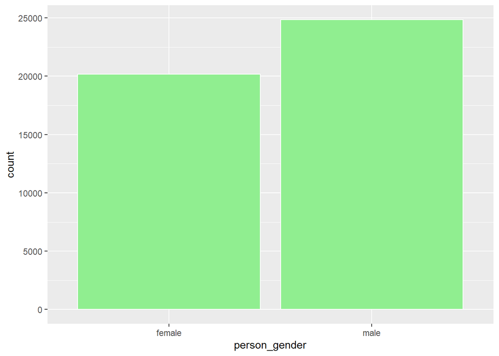

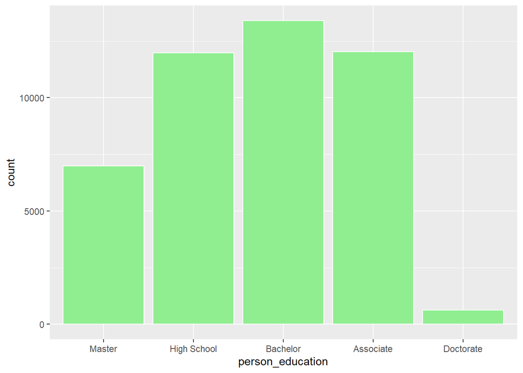

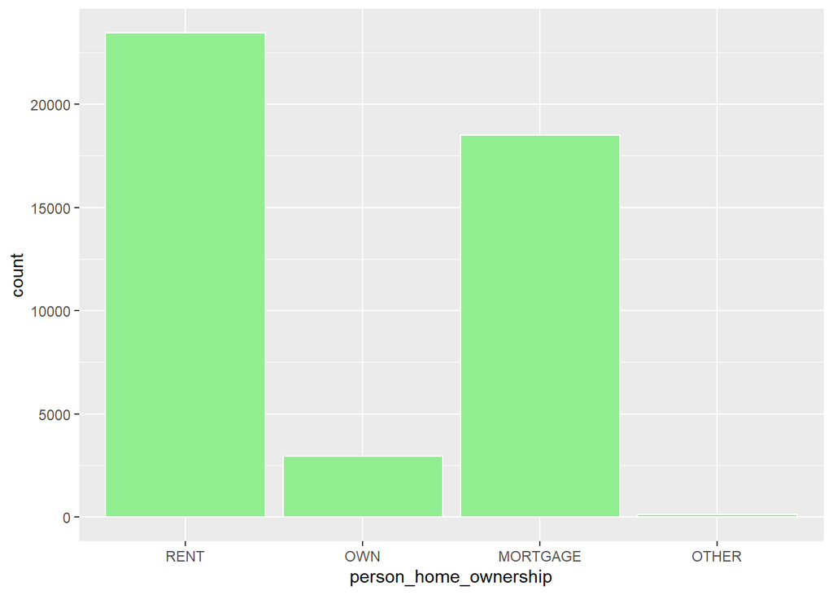

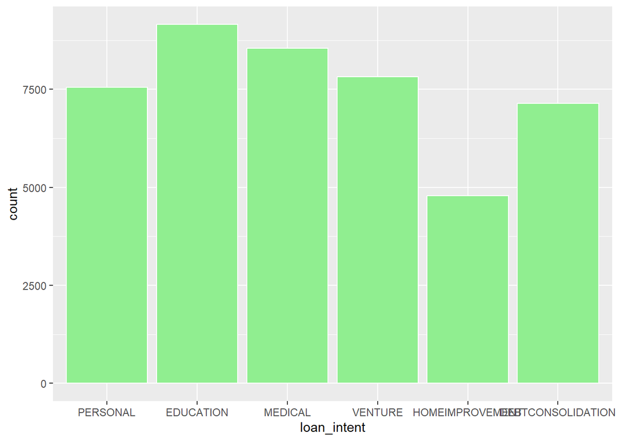

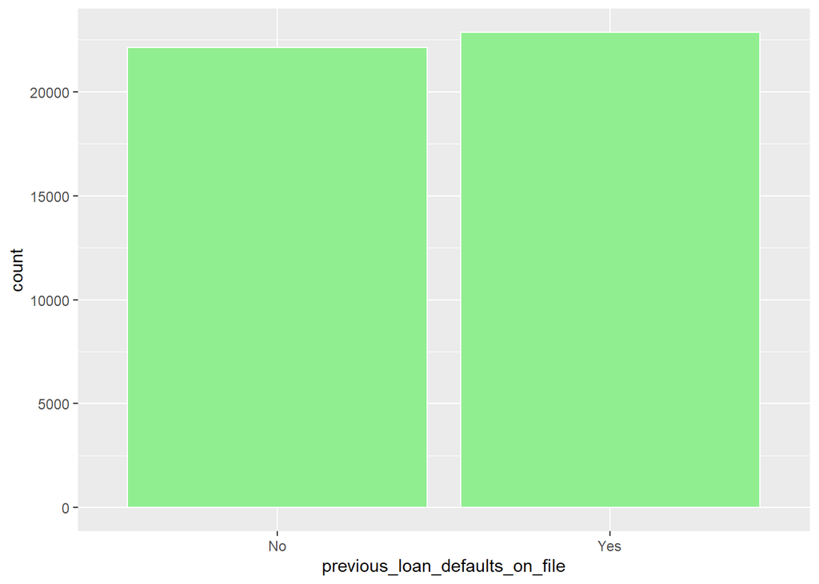

```r
ggplot(loan, aes(x=person_gender)) + geom_bar(stat="count", fill = "lightgreen", col = "white")

ggplot(loan, aes(x=person_education)) + geom_bar(stat="count", fill = "lightgreen", col = "white")

ggplot(loan, aes(x=person_home_ownership)) + geom_bar(stat="count", fill = "lightgreen", col = "white")

ggplot(loan, aes(x=loan_intent)) + geom_bar(stat="count", fill = "lightgreen", col = "white")

ggplot(loan, aes(x=previous_loan_defaults_on_file)) + geom_bar(stat="count", fill = "lightgreen", col = "white")
```

### Correlation

Below the data down to just the numerical data and looks at the correlation between these variables.

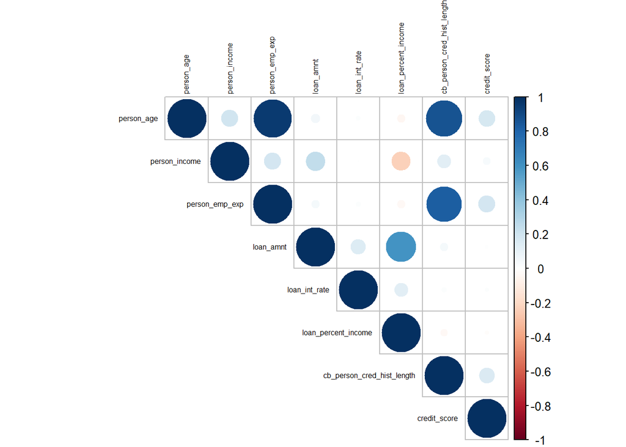

```r
loan_numeric <- select_if(loan, is.numeric)
correlation <- cor(loan_numeric, method = "pearson")
corrplot(correlation, number.cex = .9, method = "circle", type = "upper", tl.cex=0.5,tl.col = "black")
```

Here we can see that there are several varaibles that are strongly correlated. These are person age, the number of years of employment experience that they have and the umber of years of credit history they have. This is to be expected as age limits how both of these other variables. Also note that a persons income is ever so slightly negatively correlated with the loan percentage amount.

## Data Cleaning

As seen earlier, there are some extreme outlilers in the variables person_age, person_income and person_emp_exp so these should be removed before modelling. Instead of using plots to decide where the outliers are, we will use the interquartile range. outliers will be classed as anything 1.5 x the interquatile higher than the third quartile.

```r
higher_fence <- function(data) {
  Q <- quantile(data, probs = 0.75)
  IQR <- IQR(data)
  higher_fence <- Q + 1.5*IQR
  return(higher_fence)
}

higher_fence_age <- higher_fence(loan$person_age)
higher_fence_income <- higher_fence(loan$person_income)
higher_fence_emp_exp <- higher_fence(loan$person_emp_exp)

loan_original <- loan

loan <- loan %>% mutate(person_age =ifelse(person_age > higher_fence_age, NA, person_age)) %>%
  mutate(person_income =ifelse(person_income > higher_fence_income, NA, person_income)) %>%
  mutate(person_emp_exp =ifelse(person_emp_exp > higher_fence_emp_exp, NA, person_emp_exp))

# Review how many NAs that has added to the data

sapply(loan, function(x) sum(is.na(x)))
```

```
##                     person_age                  person_gender
##                           2188                              0
##               person_education                  person_income
##                              0                           2218
##                 person_emp_exp          person_home_ownership
##                           1724                              0
##                      loan_amnt                    loan_intent
##                              0                              0
##                  loan_int_rate            loan_percent_income
##                              0                              0
##     cb_person_cred_hist_length                   credit_score
##                              0                              0
## previous_loan_defaults_on_file                    loan_status
##                              0                              0
```

```r
sum(is.na(loan))
```

```
## [1] 6130
```

```r
# Remove variables no longer needed

rm(higher_fence, higher_fence_age, higher_fence_emp_exp, higher_fence_income)
```

This has not added too many NAs to the data so I do not think they need removing.

Below are boxplots of the above three variables with outliers removed using the above method (on the left) and the original data (on the right).

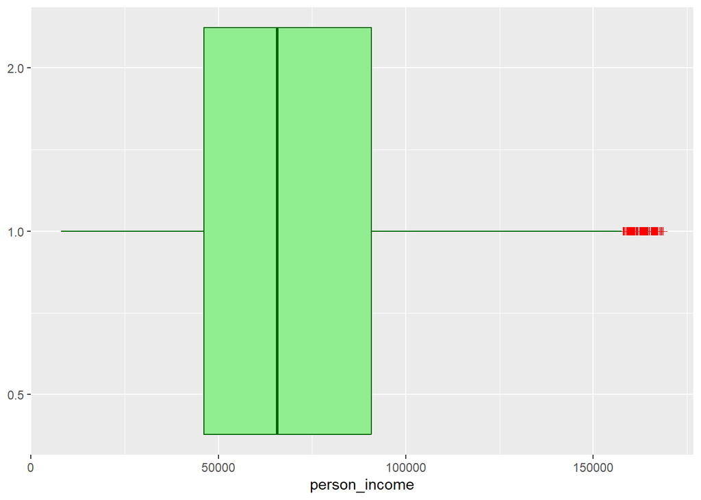

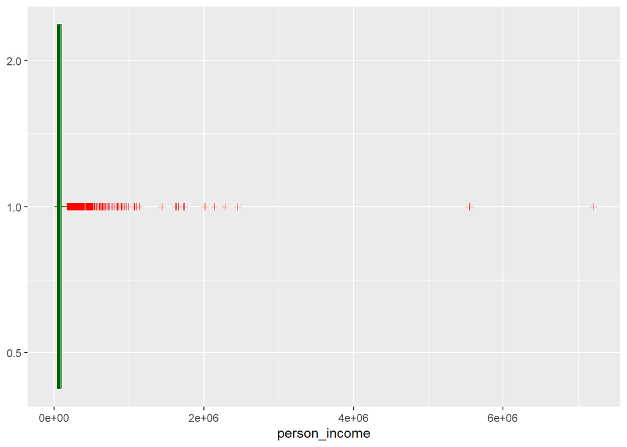

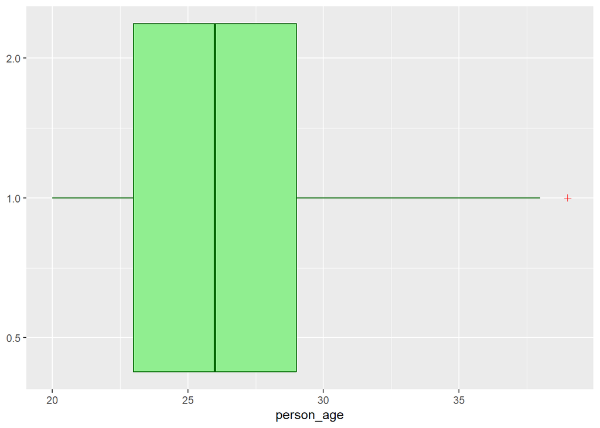

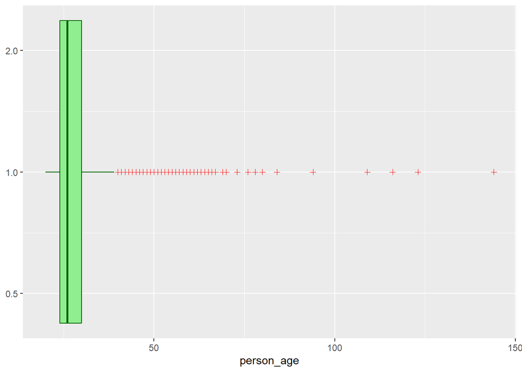

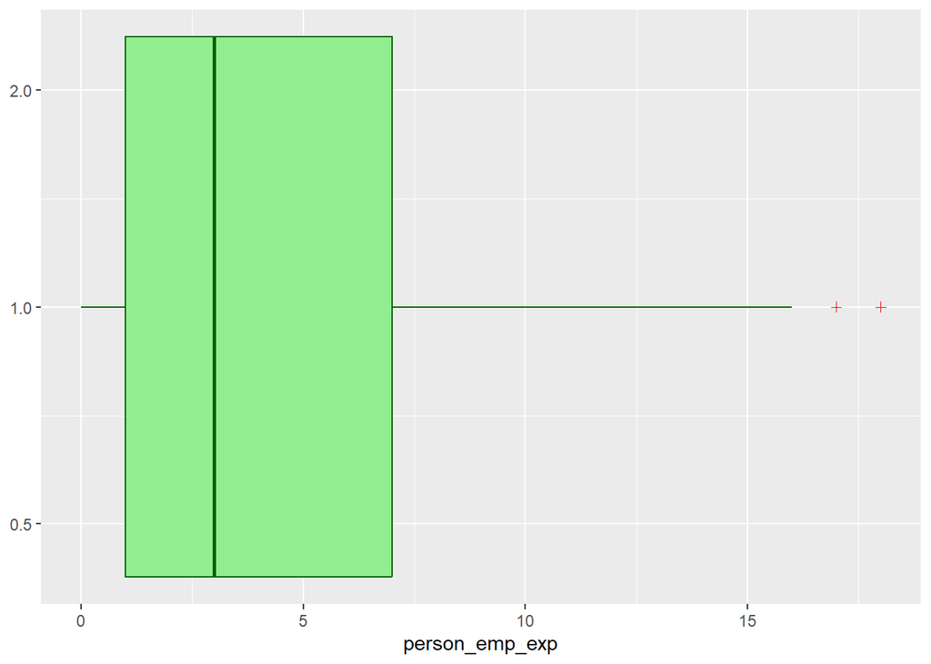

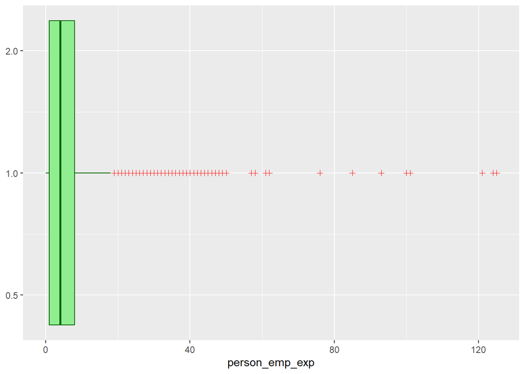

```r
loan %>% ggplot(aes(person_income)) + scale_y_log10() +
  geom_boxplot(outlier.shape = 3, outlier.color = "red", fill = "lightgreen", color = "darkgreen")
loan_original %>% ggplot(aes(person_income)) + scale_y_log10() +
  geom_boxplot(outlier.shape = 3, outlier.colour = "red", fill = "lightgreen", color = "darkgreen")

loan %>% ggplot(aes(person_age)) + scale_y_log10() +
  geom_boxplot(outlier.shape = 3, outlier.color = "red", fill = "lightgreen", color = "darkgreen")
loan_original %>% ggplot(aes(person_age)) + scale_y_log10() +
  geom_boxplot(outlier.shape = 3, outlier.colour = "red", fill = "lightgreen", color = "darkgreen")

loan %>% ggplot(aes(person_emp_exp)) + scale_y_log10() +
  geom_boxplot(outlier.shape = 3, outlier.color = "red", fill = "lightgreen", color = "darkgreen")
loan_original %>% ggplot(aes(person_emp_exp)) + scale_y_log10() +
  geom_boxplot(outlier.shape = 3, outlier.colour = "red", fill = "lightgreen", color = "darkgreen")
```

From these, we can observe that the distribution of these variables now has a smaller spread after taking out the extreme values. This may be advantageous when modelling.

## Model Building

First when buidling a model the data needs to be split into a training data set and a test data set. We will then look at the porportion of loans accepted and loans rejected both of these data sets and the whole data set.

```r
set.seed(1234)
sample_index <- sample(nrow(loan), round(nrow(loan) * .75), replace = FALSE)

train_data <- loan[sample_index, ]
test_data <- loan[-sample_index, ]

round(prop.table(table(select(loan, loan_status))), 2)
```

```
## loan_status
##    1    0
## 0.22 0.78
```

```r
round(prop.table(table(select(train_data, loan_status))), 2)
```

```
## loan_status
##    1    0
## 0.22 0.78
```

```r
round(prop.table(table(select(test_data, loan_status))), 2)
```

```
## loan_status
##    1    0
## 0.23 0.77
```

### Rpart Model

The model then needs to be trained using the following code:

```r
loan_mod <- rpart(loan_status ~ ., method = "class", data = train_data)
```

Below shows a decision tree visualisation of this model.

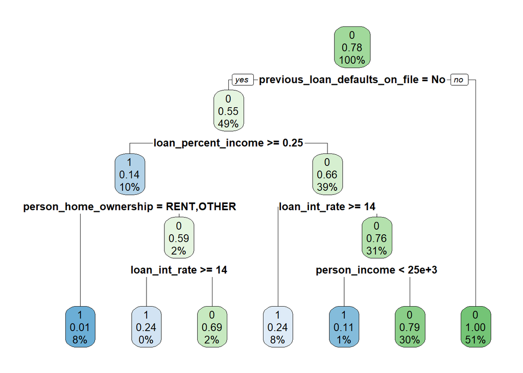

```r
rpart.plot(loan_mod)
```

This model is then used to make preditions on the test data set.

```r
loan_pred <- predict(loan_mod,test_data, type = "class")
```

### Model Evaluation

Performance measures for this model can be seen below:

```r
confusionMatrix(loan_pred, test_data$loan_status)
```

```
## Confusion Matrix and Statistics
##
##           Reference
## Prediction    1    0
##          1 1776  258
##          0  762 8454
##
##                Accuracy : 0.9093
##                  95% CI : (0.9039, 0.9146)
##     No Information Rate : 0.7744
##     P-Value [Acc > NIR] : < 2.2e-16
##
##                   Kappa : 0.7209
##
##  Mcnemar's Test P-Value : < 2.2e-16
##
##             Sensitivity : 0.6998
##             Specificity : 0.9704
##          Pos Pred Value : 0.8732
##          Neg Pred Value : 0.9173
##              Prevalence : 0.2256
##          Detection Rate : 0.1579
##    Detection Prevalence : 0.1808
##       Balanced Accuracy : 0.8351
##
##        'Positive' Class : 1
##
```

These measures show this is fairly accurate model and should perform highly.